# Applied Data Science Final

Lan Phan

2022-11-28

```r
knitr::opts_chunk$set(echo = TRUE)
knitr::opts_chunk$set(warning = FALSE)

library(dplyr)
library(tidyverse)
```

```r
library(ggplot2)
library(readxl)
library(data.table)
library(RColorBrewer)
```

# Tidy Data

A series of steps was taken to compile, clean, and sort the various data sets used in this paper. The attached markdown document reflects the initial process.

## Import Datasets

As some datasets used full state names while others only had abbreviations, I made an excel spreadsheet called statetranslation in order to connect different datasets based on states. The statetranslation document only had 2 variables, one for full state names, the other is the abbreviation.

```r
statetranslation <- read_xlsx("/Users/lanphan/Desktop/Academics/PhD Research/GitHub-R-Codes/AppliedDataScience/StateTranslation.xlsx")

#US Census Data 2020
censusdat <- read_csv("/Users/lanphan/Desktop/Academics/PhD Research/GitHub-R-Codes/AppliedDataScience/censusclean2020.csv")
censusdat <- censusdat %>%
  mutate(rWhite = White/ PopEstimate,
         rBlack = Black/ PopEstimate,
         rAsian = Asian/ PopEstimate,
         rNative = Native/ PopEstimate,
         rOther = Other/ PopEstimate,
         rMixed = `Inter-racial`/ PopEstimate)

#police violence data
policeviolence <- read_csv("/Users/lanphan/Desktop/Academics/PhD Research/GitHub-R-Codes/AppliedDataScience/policeviolence2018-2021.csv")
# hatecrime count from 2018-2020
hatecrime <- read_csv("/Users/lanphan/Desktop/Academics/PhD Research/GitHub-R-Codes/AppliedDataScience/hatecrime2018-2020.csv")
#tweet count related to BLM
tweetcount <- read_csv("/Users/lanphan/Desktop/Academics/PhD Research/GitHub-R-Codes/AppliedDataScience/blmtweetcount2018-2021.csv")
#demonstrations count 2018
ccc2018 <- read_csv("/Users/lanphan/Desktop/Academics/PhD Research/GitHub-R-Codes/AppliedDataScience/ccc2018.csv")
ccc2018$StateTerritory <- toupper(ccc2018$StateTerritory) #make sure all abbreviations are uppercase
```

# Data Visualization

## Heatmap

```r
#packages
library(ComplexHeatmap)
library(hopach)
library(circlize)
#function uncentered correlation and average linkage
uncenter.dist<-function(m) {
  as.dist(as.matrix(distancematrix(m, d="cosangle")))
}


best_col = colorRamp2(c(-2, 0, 2), c("#82A3FF", "grey", "#8B2E2E"))


#Setting up= for the 2018 heatmap

#counting hate crime in 2018
hcsum2018 <- hatecrime %>%
  filter(DATA_YEAR == 2018) %>%
  group_by(STATE_ABBR) %>%
  summarize(HateCrime = n())

pvsum2018 <- policeviolence %>%
  filter(year == 2018) %>%
  group_by(state) %>%
  summarize(PoliceViolence = n())


datsum2018 <- censusdat %>%
  left_join(statetranslation,
             by = c("NAME" = "Name"))

datsum2018 <- datsum2018 %>%
  left_join(hcsum2018,
            by = c("Abbrev" = "STATE_ABBR")) %>%
  left_join(pvsum2018,
            by = c("Abbrev" = "state")) %>%
  mutate(rHateCrime = (HateCrime/ PopEstimate)*100,
         rPoliceViolence = (PoliceViolence/ PopEstimate)*100) %>%
  dplyr::select(NAME,
         rWhite, rBlack, rNative, rAsian, rOther, rMixed,
         rPoliceViolence, rHateCrime)

hm2018dat<-datsum2018[, c(2:9)]

#name the heatmap rows to their states
rownames(hm2018dat) <- datsum2018$NAME

#z-scoring the data
hm2018dat.scale<-scale(hm2018dat)

#uncentered correlation and average linkage

row.clus18<-hclust(uncenter.dist(hm2018dat.scale), method = "ave")
col.clus18<-hclust(uncenter.dist(t(hm2018dat.scale)), method = "ave")

ht2018 = Heatmap(hm2018dat.scale, name = "2018 Heatmap",
        cluster_rows=row.clus18, cluster_columns=col.clus18,
        na_col = "white", col = best_col,
        row_names_gp = gpar(fontsize = 5))
```

```r
#2019 Heatmap

#Setting up for the 2019 heatmap

hcsum2019 <- hatecrime %>%
  filter(DATA_YEAR == 2019) %>%
  group_by(STATE_ABBR) %>%
  summarize(HateCrime = n())

pvsum2019 <- policeviolence %>%
  filter(year == 2019) %>%
  group_by(state) %>%
  summarize(PoliceViolence = n())


datsum2019 <- censusdat %>%
  left_join(statetranslation,
             by = c("NAME" = "Name"))

datsum2019 <- datsum2019 %>%
  left_join(hcsum2019,
            by = c("Abbrev" = "STATE_ABBR")) %>%
  left_join(pvsum2019,
            by = c("Abbrev" = "state")) %>%
  mutate(rHateCrime = (HateCrime/ PopEstimate)*100,
         rPoliceViolence = (PoliceViolence/ PopEstimate)*100) %>%
  dplyr::select(NAME,
         rWhite, rBlack, rNative, rAsian, rOther, rMixed,
         rPoliceViolence, rHateCrime)

hm2019dat<-datsum2019[, c(2:9)]

#name the heatmap rows to their states
rownames(hm2019dat) <- datsum2019$NAME

#z-scoring the data
hm2019dat.scale<-scale(hm2019dat)

#uncentered correlation and average linkage

row.clus19<-hclust(uncenter.dist(hm2019dat.scale), method = "ave")
col.clus19<-hclust(uncenter.dist(t(hm2019dat.scale)), method = "ave")

ht2019 = Heatmap(hm2019dat.scale, name = "2019 Heatmap",
        cluster_rows=row.clus19, cluster_columns=col.clus19,
        na_col = "white", col = best_col,
        row_names_gp = gpar(fontsize = 5))
```

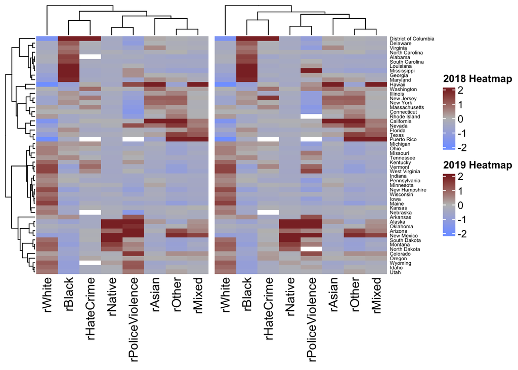

```r
ht2018 + ht2019
```

```r
#SHOULD DEFINITELY ADD MORE YEARS
```

## Heatmap Maps!

(officially known as Choropleth)

Parts of the codes are from: https://rdvark.net/2021/12/29/pretty-choropleth-maps-with-sf-and-ggplot2/

For 2018

```r
library(leaflet)
library(sf)
```

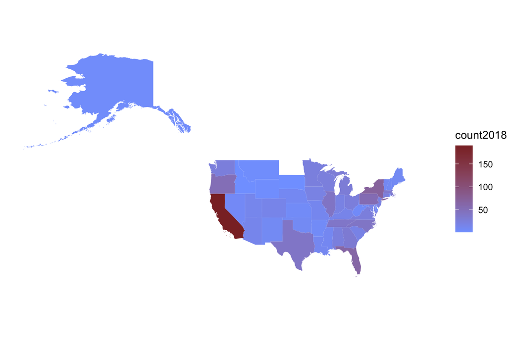

```r
#importing the shape of the U.S.
usmap <- read_sf("/Users/lanphan/Desktop/Academics/PhD Research/GitHub-R-Codes/AppliedDataScience/gz_2010_us_040_00_5m.json")


choroplot18 <- ccc2018 %>%
  group_by(StateTerritory) %>%
  summarize(count2018 = n()) %>%
  right_join(statetranslation,
             by = c("StateTerritory" = "Abbrev")) %>%
  inner_join(censusdat,
             by = c("Name" = "NAME")) %>%
  mutate(ratio2018 = (count2018/PopEstimate)*100) %>%
  inner_join(usmap,
             by = c("Name" = "NAME"))

#turn back into a sf object for geom_sf to map out data
choroplot18 <- st_as_sf(choroplot18)


#### Just by count
choroplot18 %>%
  ggplot(aes(fill = count2018)) + # create a ggplot object and
  # change its fill colour according to median_age
  geom_sf(colour = NA) +# plot all local authority geometries
  scale_fill_gradient(low = "#82A3FF",
                      high = "#8B2E2E", na.value = "white") +
  coord_sf(xlim = c(-180, -60), lims_method = "box") + #just zoom in the U.S.
  theme_void() #remove background
```

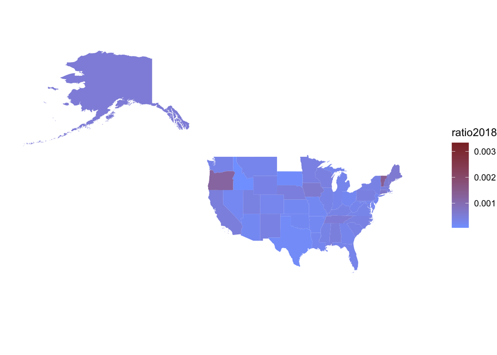

```r
#### By ratio of the population
choroplot18 %>%
  ggplot(aes(fill = ratio2018)) + # create a ggplot object and
  # change its fill colour according to median_age
  geom_sf(colour = NA) +# plot all local authority geometries
  scale_fill_gradient(low = "#82A3FF",
                      high = "#8B2E2E", na.value = "white") +
  coord_sf(xlim = c(-180, -60), lims_method = "box") + #just zoom in the U.S.
  theme_void() #remove background
```

```r
#finally omg
#so beautiful imma cry
#also work with plotly
```

# Data Analysis

## Topic Modeling

The codes are from

Bowers, A.J., Chen, J.(2015) Ask and Ye Shall Receive? Automated Text Mining of Michigan Capital Facility Finance Bond Election Proposals to Identify which Topics are Associated with Bond Passage and Voter Turnout. Journal of Education Finance, 41(2), p.164-196. http://dx.doi.org/10.7916/D8FJ2GDH

```r
library(topicmodels)
library(tm)
library(tidytext)
library(tidyr)
library(slam)
library(ggrepel)
library(MASS)
library(textstem)
library(readtext)
```

### 2018 Reddit Data

```r
#package to change the time into something that makes sense
library(anytime)

#Importing Reddit Data for 2018
comments2018 <- fread("/Volumes/Lan's 4TB Drive/Big Data Sets/BLMReddit/reddit2018comments.csv", na.string = "")

posts2018 <- fread("/Volumes/Lan's 4TB Drive/Big Data Sets/BLMReddit/reddit2018posts.csv", na.string = "")

#reshaping 2018 data by matching post and comments together based on the post_id
all2018 <- posts2018[comments2018, on = c(id = "submission")] #right_joining

all2018$time_created <- anydate(all2018$time_created)

all2018 <- all2018 %>%
  separate(time_created, into = c("year", "month", "date"), sep = "-", remove = FALSE)

all2018 <- all2018[year == 2018]

colnames(all2018)
```

```
##  [1] "...1"                "time_created"        "year"
##  [4] "month"               "date"                "title"
##  [7] "post_flair"          "score"               "upvote_ratio"
## [10] "id"                  "url"                 "comms_num"
## [13] "created"             "body"                "author"
## [16] "author_flair"        "subreddit"           "V1"
## [19] "comment_id"          "comment_parent_id"   "comment_body"
## [22] "comment_score"       "comment_link_id"     "comment_author"
## [25] "comment_issubmitter" "comment_forest"
```

```r
summary(all2018)
```

```
##       ...1    time_created            year              month
##  Min.   :0   Min.   :2018-01-22   Length:21001       Length:21001
##  1st Qu.:0   1st Qu.:2018-02-20   Class :character   Class :character
##  Median :0   Median :2018-03-22   Mode  :character   Mode  :character
##  Mean   :0   Mean   :2018-04-17
##  3rd Qu.:0   3rd Qu.:2018-05-25
##  Max.   :0   Max.   :2018-12-21
##      date              title            post_flair            score
##  Length:21001       Length:21001       Length:21001       Min.   :   0
##  Class :character   Class :character   Class :character   1st Qu.:   7
##  Mode  :character   Mode  :character   Mode  :character   Median :  46
##                                                           Mean   :1039
##                                                           3rd Qu.: 433
##                                                           Max.   :8239
##   upvote_ratio         id                url              comms_num
##  Min.   :0.1300   Length:21001       Length:21001       Min.   :  1.0
##  1st Qu.:0.5900   Class :character   Class :character   1st Qu.: 50.0
##  Median :0.8000   Mode  :character   Mode  :character   Median :117.0
##  Mean   :0.7484                                         Mean   :214.4
##  3rd Qu.:0.9200                                         3rd Qu.:248.0
##  Max.   :1.0000                                         Max.   :985.0
##     created              body              author          author_flair
##  Min.   :1.517e+09   Length:21001       Length:21001       Length:21001
##  1st Qu.:1.519e+09   Class :character   Class :character   Class :character
##  Median :1.522e+09   Mode  :character   Mode  :character   Mode  :character
##  Mean   :1.524e+09
##  3rd Qu.:1.527e+09
##  Max.   :1.545e+09
##   subreddit              V1             comment_id        comment_parent_id
##  Length:21001       Length:21001       Length:21001       Length:21001
##  Class :character   Class :character   Class :character   Class :character
##  Mode  :character   Mode  :character   Mode  :character   Mode  :character
##
##
##
##  comment_body       comment_score      comment_link_id    comment_author
##  Length:21001       Min.   :-181.000   Length:21001       Length:21001
##  Class :character   1st Qu.:   1.000   Class :character   Class :character
##  Mode  :character   Median :   2.000   Mode  :character   Mode  :character
##                     Mean   :   4.869
##                     3rd Qu.:   4.000
##                     Max.   :2038.000
##  comment_issubmitter comment_forest
##  Mode :logical       Length:21001
##  FALSE:18628         Class :character
##  TRUE :2373          Mode  :character
##
##
##
```

```r
#Divide up into subreddits


#Discussion-based
#politics, politicaldiscussion, and neutralpolitics
discussion2018 <- all2018[subreddit %in% c("politics", "politicaldiscussion", "neutralpolitics")]
discussion2018p <- posts2018[subreddit %in% c("politics", "politicaldiscussion", "neutralpolitics")] #just post titles


#opinion-based
# changemyview, politicalopinions
opinion2018 <- all2018[subreddit %in% c("changemyview", "politicalopinions")]
opinion2018p <- posts2018[subreddit %in% c("changemyview", "politicalopinions")] #just post titles



#query-based
#asktrumpsupporters and ask_politics
query2018 <- all2018[subreddit %in% c("asktrumpsupporters", "ask_politics")]
#none in 2018
```

#### Discussion-Based Subreddits

```r
#random select 100 rows cause it is too much
ctmdat <- sample_n(discussion2018p, 200)
```

*Learning Notes from Dr. Bowers* topicmodels and tm needs a very specific type of data, called a DocumentTermMatrix. We’ll call specific corpus and DocumentTermMatrix functions here to create the data matrix required for the topic model.

Note here that this is where we stem, stopword, set the min word length, remove numbers, and remove punctuation.

So this sets up our data matrix DTM. We then need to know how to set “alpha” the hyperparameter, so we need some information on the tfidf (term frequency-inverse document frequency)

```r
#Build CMT
corpus <- Corpus(VectorSource(ctmdat$title))
corpus
```

```
## <<SimpleCorpus>>
## Metadata:  corpus specific: 1, document level (indexed): 0
## Content:  documents: 200
```

```r
#text manipulation
text_DTM <- DocumentTermMatrix(corpus, control = list(stemming = TRUE, stopwords = TRUE, minWordLength = 3,
                                                      removeNumbers = TRUE, removePunctuation = TRUE))
text_DTM
```

```
## <<DocumentTermMatrix (documents: 200, terms: 764)>>
## Non-/sparse entries: 1793/151007
## Sparsity           : 99%
## Maximal term length: 17
## Weighting          : term frequency (tf)
```

```r
term_tfidf <- tapply(text_DTM$v / row_sums(text_DTM)[text_DTM$i], text_DTM$j, mean) * log2(nDocs(text_DTM)/col_sums(text_DTM > 0))
summary(term_tfidf)
```

```
##    Min. 1st Qu.  Median    Mean 3rd Qu.    Max.
## 0.01687 0.62195 0.70130 0.76258 0.84932 3.02945
```

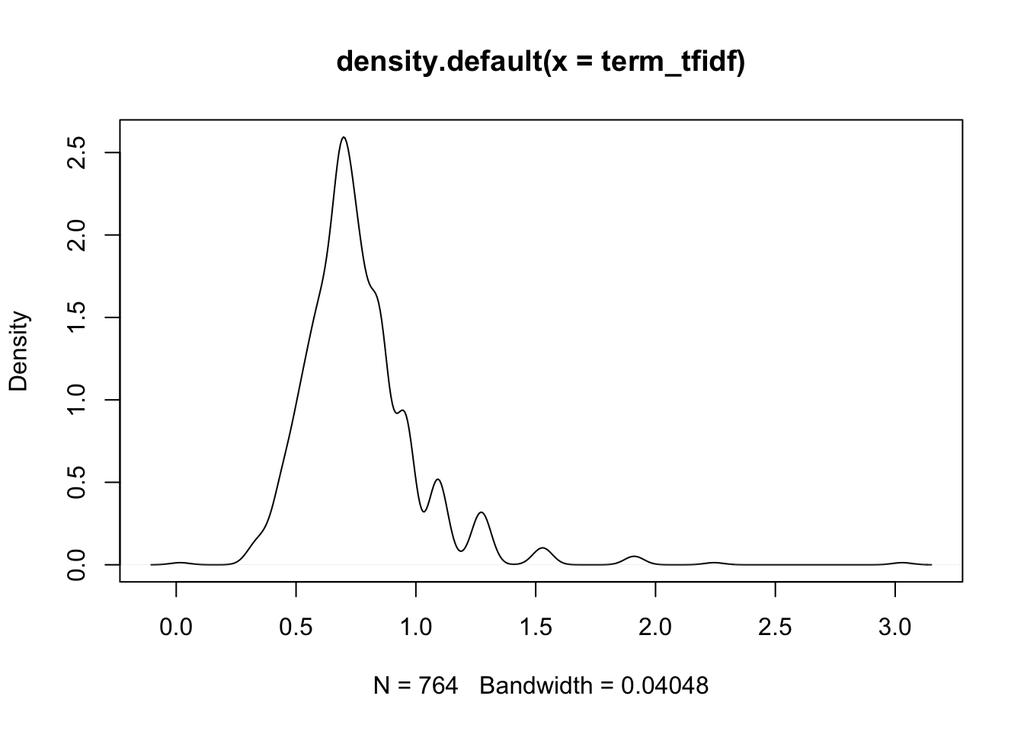

```r
plot(density(term_tfidf))
```

Rule of thumb is to use the median from the graph for alpha. Here it’s around 0.7. We will cut down the total number of terms by setting alpha so that we don’t have too many common terms no unique ones.

```r
alpha <- 0.7 #is the median
text_DTM_trimmed <- text_DTM[row_sums(text_DTM) >0, term_tfidf >= alpha]
dim(text_DTM_trimmed)
```

```
## [1] 200 391
```

*10-fold Cross Validation*

We set up the 10 fold cross validation, selecting 10% of the data for each of the 10 folds

```r
# Cross validation

control_CTM_VEM <- list(
  estimate.beta = TRUE, verbose = 0, prefix = tempfile(), save = 0, keep = 0,
  seed = as.integer(Sys.time()), nstart=1L, best = TRUE,
  var = list(iter.max=100, tol=10^-6),
  em = list(iter.max=500, tol=10^-4),
  cg = list(iter.max=100, tol=10^5)
)

# use 10-fold CV to determine k!
# randomly divide the data into 10 folds.

set.seed(123)
topics <- c(2, 3, 4, 5, 6, 7, 8, 9, 10, 15) ##set k equals to 2 3 4 5 6 7 8 9 10 15.
seed <- 2
D <- length(ctmdat$title)
folding <- sample(rep(seq_len(10), ceiling(D))[seq_len(D)])
table(folding)
```

```
## folding
##  1  2  3  4  5  6  7  8  9 10
## 20 20 20 20 20 20 20 20 20 20
```

*Learning Notes* We train and test using the 10-fold cross validation that we just set up. Then plot by perplexity to see where the elbow is to select the correct number of topics k

Note: This can take a bit of time.

```r
#the code originally did not work because there were columns that had all 0 responses
#so we had to remove them
raw.sum = apply(text_DTM_trimmed, 1, FUN = sum)
text_DTM_trimmed = text_DTM_trimmed[raw.sum!= 0,]


## write a loop to automatically output the perplexity
perp_by_col <- vector()
for (k in topics) {
  perp_by_row <- vector()
  for (chain in seq_len(10)) {
    training <- CTM(text_DTM_trimmed[folding != chain,], k = k,
                    control = control_CTM_VEM)
    testing <- CTM(text_DTM_trimmed[folding == chain,], model = training,
                   control = control_CTM_VEM)
    perp_by_row <- rbind(perp_by_row, perplexity(testing))
  }
  perp_by_col <- cbind(perp_by_col, perp_by_row)
}

#wow this is indeed taking forever
```

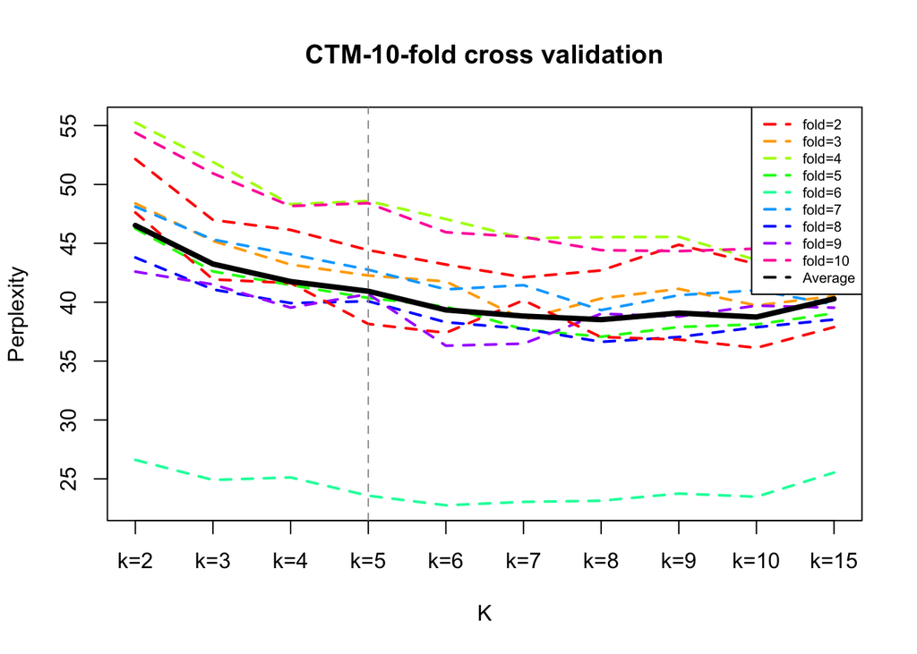

```r
# Plot perplexity
transpose <- t(perp_by_col)
matplot(transpose, type = "l", col = rainbow(9), lty = 2, lwd = 2, ylab = "Perplexity", xlab = "K", main = "CTM-10-fold cross validation", xaxt="n")
axis(1, at=1:10, labels = c("k=2", "k=3", "k=4", "k=5", "k=6", "k=7", "k=8", "k=9", "k=10", "k=15"), cex=0.5)

perp_by_col_mean <- colMeans(perp_by_col)

lines(perp_by_col_mean, col = "black", lwd = 4, lty = 1)
led <- c("fold=2", "fold=3", "fold=4", "fold=5", "fold=6", "fold=7", "fold=8", "fold=9", "fold=10", "Average")
legend("topright", led, lwd = 2, lty = 2, col = c(rainbow(9), 'black'), cex = 0.65)

abline(v = 4, col = "gray60", lty = 2)
```

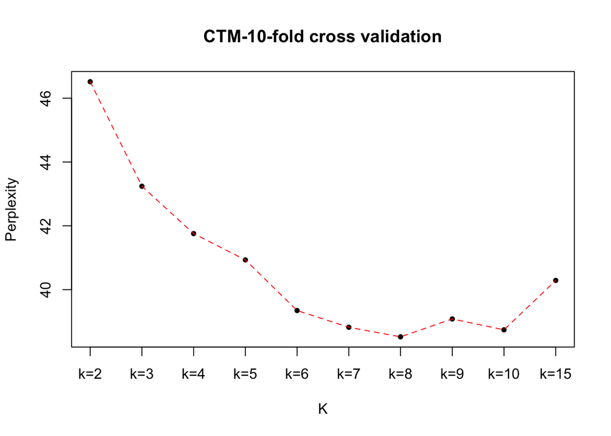

```r
{plot(perp_by_col_mean, pch = 20, ylab = 'Perplexity', xlab = "K", main = "CTM-10-fold cross validation",
      xaxt = "n")
  axis(1, at = 1:10, labels = c("k=2","k=3","k=4","k=5","k=6","k=7","k=8","k=9","k=10","k=15"), cex = 0.5)
  lines(perp_by_col_mean, lwd = 1, lty = 2, col = "red")}
```

*Correlated Topic Model* Running 9 correlated topic model

```r
control_CTM_VEM1 <- list(
  estimate.beta = TRUE, verbose=0, prefix=tempfile(),save=0,keep=0,
  seed=1421313709,nstart=1L,best=TRUE,
  var=list(iter.max=500,tol=10^-6),
  em=list(iter.max=1000,tol=10^-4),
  cg=list(iter.max=500,tol=10^5)
)

################## K = 9 ##################

CTM3 <- CTM(text_DTM_trimmed, k = 9, control = control_CTM_VEM1)
CTM3
```

```
## A CTM_VEM topic model with 9 topics.
```

*Examining the Topic Output*

```r
## Table the documents by topics
main_topic_table3 <- as.data.frame(table(topics(CTM3)))
colnames(main_topic_table3) <- c("Topic", "Frequency")
print(main_topic_table3)
```

```
##   Topic Frequency
## 1     1        15
## 2     2        20
## 3     3        40
## 4     4        18
## 5     5        11
## 6     6        10
## 7     7        16
## 8     8        19
## 9     9         2
```

```r
#what are the top 10 words for the 3 topics
terms(CTM3,10)
```

```
##       Topic 1     Topic 2   Topic 3    Topic 4    Topic 5      Topic 6
##  [1,] "spi"       "hospit"  "disput"   "power"    "like"       "rape"
##  [2,] "poison"    "america" "assault"  "make"     "hear"       "steve"
##  [3,] "lawyer"    "bomb"    "brawl"    "congress" "save"       "baltimor"
##  [4,] "murder"    "fake"    "answer"   "illeg"    "state’"     "tell"
##  [5,] "sever"     "indian"  "gave"     "nashvill" "washington" "isi"
##  [6,] "time"      "launch"  "univers"  "ran"      "seiz"       "explos"
##  [7,] "american"  "respons" "threaten" "stori"    "gunfir"     "left"
##  [8,] "slash"     "support" "new"      "sue"      "‘orwellian" "post"
##  [9,] "malaysian" "utah"    "facebook" "polici"   "‘we"        "propaganda"
## [10,] "‘get"      "jr’s"    "recruit"  "crimin"   "away"       "wynn"
##       Topic 7    Topic 8     Topic 9
##  [1,] "crisi"    "church"    "delet"
##  [2,] "fund"     "netanyahu" "user"
##  [3,] "peopl"    "corrupt"   "oust"
##  [4,] "hostag"   "disarm"    "expos"
##  [5,] "put"      "recommend" "panamanian"
##  [6,] "savannah" "drug"      "carolina"
##  [7,] "spend"    "possibl"   "lobbi"
##  [8,] "suspend"  "prime"     "evict"
##  [9,] "weapon"   "texa"      "staff"
## [10,] "brutal"   "hand"      "outrag"
```

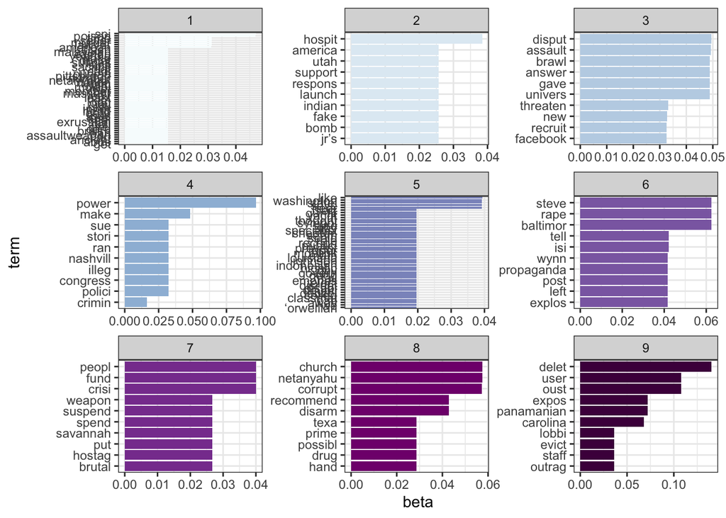

```r
# Using this: https://www.tidytextmining.com/topicmodeling.html
# Use tidyverse to look at the CTM results a bit more more

tidy_topics <- tidy(CTM3, matrix = "beta")

top_terms <- tidy_topics %>%
  group_by(topic) %>%
  slice_max(beta, n = 10) %>%
  ungroup() %>%
  arrange(topic, -beta)

top_terms %>%
  mutate(term = reorder_within(term, beta, topic)) %>%
  ggplot(aes(beta, term, fill = factor(topic))) +
  geom_col(show.legend = FALSE) +
  facet_wrap(~ topic, scales = "free") +
  scale_fill_brewer(palette = "BuPu") +
  scale_y_reordered() +
  theme_bw()
```